# Conversion between Lux and Exposure Values

*How to determine exposure from LED panels Lux specifications, for photographers*

As a consequence of LED panels are getting cheaper and more readily available, photographers may consider using them as a substitute to strobes. With LED panels I mean small, battery powered continuous light sources normally used by vloggers and amateur videographers, not the powerful continuous lights used in photography studios or film sets. These panels are the size and weight of small strobe units and can be mounted on the camera hot shoe. In fact the form factor is quite convenient: being very similar to smartphones, these small panels fit easily in a pocket and would be comfortable to carry. Additionally, they work independently form the camera system, allowing, for instance, their use on vintage film cameras equipped with only a “cold shoe”.

The downside of these units is that they are far less powerful than strobes of equivalent size. However, determining the light output generated by these lights in units of measure typically used in photography is not straightforward. Indeed, LED panes’ specifications for what concerns light output are normally expressed in Lux (lx) measured at a certain distance from the source. When considering whether a specific LED panel would be of much use for a photographer, it would be useful to know the Exposure Value (EV) that corresponds to the panel specification: what ISO, shutter speed and aperture values are needed to correctly expose an object illuminated by the panel from a given distance?

Luckily, we can convert between EV and lx. That is to say that it is possible to determine the photographic exposure necessary to photograph an object receiving a given amount of light expressed in lx. The conversion formula found on [Wikipedia](http://en.wikipedia.org/wiki/Exposure_value#EV_as_a_measure_of_luminance_and_illuminance) is simple:

[figure not shown]

Where “*E*” is illuminance in Lux, and “EV” is the Exposure Value at ISO 100 (this corresponds to the Light Value (LV)).

I was interested in a very portable panel for use in macro-photography, as main light for a dark scenes with a subject in portrait range (1-2 m for 50 mm lens). An example of such tool is the [Lume Cube Light Go](https://lumecube.com/products/panel-go) which is rated at 1080 lx measured 0.5 metres away. I wanted to know if I could use such a light for the above setting. Would this panel be capable of emitting enough light to shoot hand-held when focussing at 1 m with ISO 400 film and a 50 mm f:2.8 lens? With my film SLR I can hand-held sharp shots with a 50mm down to 1/60’’. This means LV7 or EV9 at ISO 400.

To do so, I wrote the conversion functions from lx to LV in R:

```r
# From Light Values to Lux
lv2lux <- function(lv) (2^lv)*2.5

# From Lux to Light Values
lux2lv <- function(lux) log(lux/2.5, 2)
```

And plotted the curve from LV5 to LV11, which represent dark settings in which the use of a flash is useful. Since light intensity is inversely proportional to the square of the distance (inverse square law), if the distance doubles, the light intensity drops by two stops (25% of intensity at original distance). So, if the panel generates 1080 lx at 0.5 m, it would generate a fourth of that (270 lx) at 1 m. What is the corresponding LV of this? We can see from the curve (and from the R code) it is a quarter of a stop less than LV7 (LV6.75).

This means that by keeping the panel on-camera, I could just barely expose for an object at 1 m away. 1.5 m if I had an f:2 lens, or if I could hand-hold 1/30’‘, and 2 m if I had an f:2 lens *and* I could hand-hold 1/30’’.

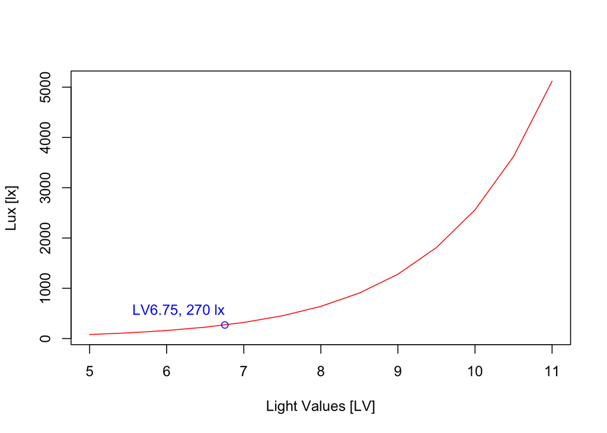

```r
# Interactive plot

lv <- seq(5,11,.5)
lux <- lv2lux(lv)
plot(lv, lux, type = "l",
     xlab = "Light Values [LV]", ylab = "Lux [lx]",
     col = "red")
points(lux2lv(1080/4), 1080/4, col = "blue")
text(lux2lv(1080/4), 1080/4, col = "blue",
     labels = paste0("LV", round(lux2lv(1080/4), 2), ", ", 1080/4, " lx"),
     adj = c(1,-1))
```

To conclude, the [Lume Cube Light Go](https://lumecube.com/products/panel-go), or any other LED panel of similar power, may just be useful in very limited circumstances, and not really be able to substitute a strobe. For an LED pane to be useful in photography, it should have a light output of at least 5120 lx at 0.5 m distance, this would be enough to illuminate a subject 2 m away with LV7.